# IODS course project

## Dimensionality reduction techniques

```r
date()
```

```
## [1] "Thu Dec 09 09:34:28 2021"
```

Before the analyses, I created a new R Markdown file, named it as ‘chapter5.Rmd’, and saved it to my folder. Then, I included the new file as a child file in my ‘index.Rmd’ file.

**FIRST, I numerically and graphically described the human data** variables and relationships across them.

```
## * `` -> ...1
```

```
##      ...1              Edu2.FM          Labo.FM          Edu.Exp
##  Length:155         Min.   :0.1717   Min.   :0.1857   Min.   : 5.40
##  Class :character   1st Qu.:0.7264   1st Qu.:0.5984   1st Qu.:11.25
##  Mode  :character   Median :0.9375   Median :0.7535   Median :13.50
##                     Mean   :0.8529   Mean   :0.7074   Mean   :13.18
##                     3rd Qu.:0.9968   3rd Qu.:0.8535   3rd Qu.:15.20
##                     Max.   :1.4967   Max.   :1.0380   Max.   :20.20
##     Life.Exp          GNI            Mat.Mor         Ado.Birth
##  Min.   :49.00   Min.   :   581   Min.   :   1.0   Min.   :  0.60
##  1st Qu.:66.30   1st Qu.:  4198   1st Qu.:  11.5   1st Qu.: 12.65
##  Median :74.20   Median : 12040   Median :  49.0   Median : 33.60
##  Mean   :71.65   Mean   : 17628   Mean   : 149.1   Mean   : 47.16
##  3rd Qu.:77.25   3rd Qu.: 24512   3rd Qu.: 190.0   3rd Qu.: 71.95
##  Max.   :83.50   Max.   :123124   Max.   :1100.0   Max.   :204.80
##     Parli.F
##  Min.   : 0.00
##  1st Qu.:12.40
##  Median :19.30
##  Mean   :20.91
##  3rd Qu.:27.95
##  Max.   :57.50
```

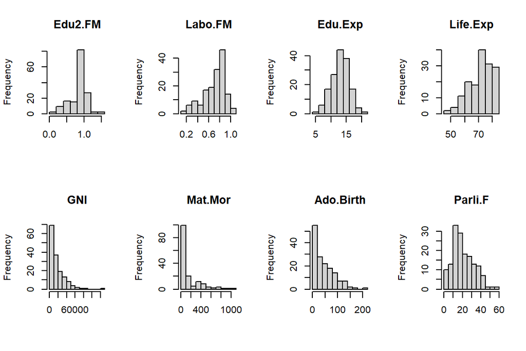

Most **human** data variables are not normally distributed. By eye, only **Edu.Exp** i.e. the expected years of schooling appears to follow a normal distribution.

```
## * `` -> ...1
```

```
##           Edu2.FM Labo.FM Edu.Exp Life.Exp   GNI Mat.Mor Ado.Birth Parli.F
## Edu2.FM      1.00    0.01    0.59     0.58  0.43   -0.66     -0.53    0.08
## Labo.FM      0.01    1.00    0.05    -0.14 -0.02    0.24      0.12    0.25
## Edu.Exp      0.59    0.05    1.00     0.79  0.62   -0.74     -0.70    0.21
## Life.Exp     0.58   -0.14    0.79     1.00  0.63   -0.86     -0.73    0.17
## GNI          0.43   -0.02    0.62     0.63  1.00   -0.50     -0.56    0.09
## Mat.Mor     -0.66    0.24   -0.74    -0.86 -0.50    1.00      0.76   -0.09
## Ado.Birth   -0.53    0.12   -0.70    -0.73 -0.56    0.76      1.00   -0.07
## Parli.F      0.08    0.25    0.21     0.17  0.09   -0.09     -0.07    1.00
```

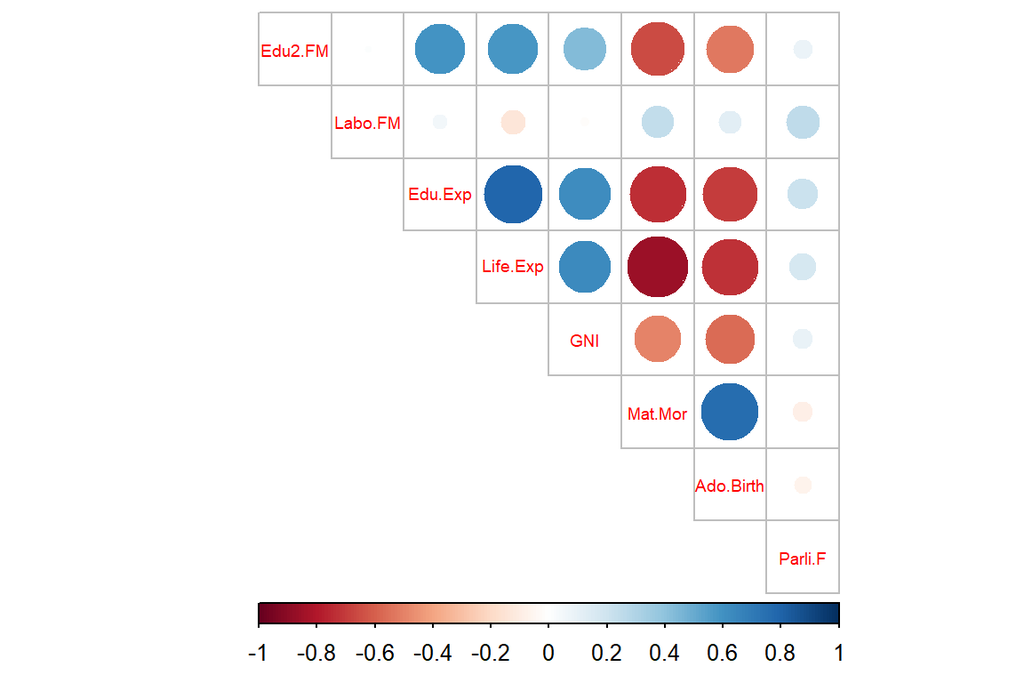

There are a few strong correlations (*r* larger than 0.70 or smaller than -0.70) across the **human** data variables. The strong positive correlations are **Edu.Exp** x **Life.Exp** (*r* = 0.79) and **Mat.Mor** x **Ado.Birth** (*r* = 0.76). Correspondingly, the strong negative correlations are **Life.Exp** x **Mat.Mor** (*r* = -0.86), **Edu.Exp** x **Mat.Mor** (*r* = -0.74), and **Life.Exp** x **Ado.Birth** (*r* = -0.73).

**SECOND, I performed the principal component analysis (PCA) on the non-standardized human data.**

```r
pca_human1 <- prcomp(human[-1])
s1 <- summary(pca_human1)
s1
```

```
## Importance of components:
##                              PC1      PC2   PC3   PC4   PC5   PC6    PC7    PC8
## Standard deviation     1.854e+04 185.5219 25.19 11.45 3.766 1.566 0.1912 0.1591
## Proportion of Variance 9.999e-01   0.0001  0.00  0.00 0.000 0.000 0.0000 0.0000
## Cumulative Proportion  9.999e-01   1.0000  1.00  1.00 1.000 1.000 1.0000 1.0000
```

```r
pca_pr1 <- round(100*s1$importance[2,], digits = 1)
pca_pr1
```

```
## PC1 PC2 PC3 PC4 PC5 PC6 PC7 PC8
## 100   0   0   0   0   0   0   0
```

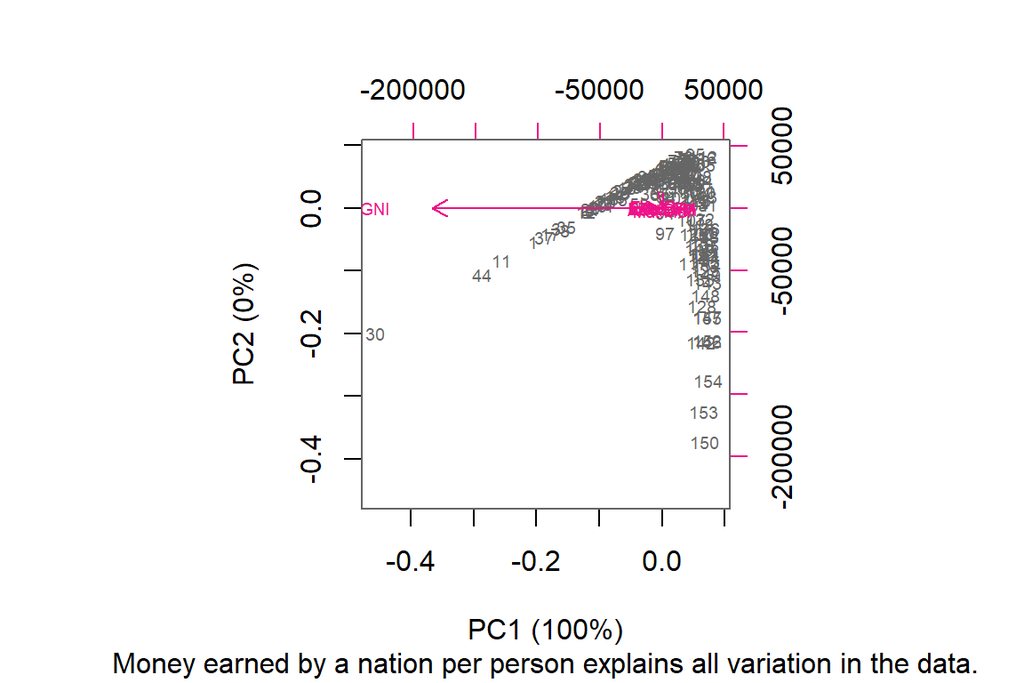

```r
pc_lab1 <- paste0(names(pca_pr1), " (", pca_pr1, "%)")
biplot(pca_human1, cex = c(0.6, 0.6), col = c("grey40", "deeppink2"), xlab = pc_lab1[1], ylab = pc_lab1[2], sub = "Money earned by a nation per person explains all variation in the data.")
```

**THIRD, I performed the principal component analysis (PCA) on the standardized human data.**

```r
human_std <- scale(human[-1])
pca_human2 <- prcomp(human_std)
s2 <- summary(pca_human2)
s2
```

```
## Importance of components:
##                           PC1    PC2     PC3     PC4     PC5     PC6     PC7
## Standard deviation     2.0708 1.1397 0.87505 0.77886 0.66196 0.53631 0.45900
## Proportion of Variance 0.5361 0.1624 0.09571 0.07583 0.05477 0.03595 0.02634
## Cumulative Proportion  0.5361 0.6984 0.79413 0.86996 0.92473 0.96069 0.98702
##                            PC8
## Standard deviation     0.32224
## Proportion of Variance 0.01298
## Cumulative Proportion  1.00000
```

```r
pca_pr2 <- round(100*s2$importance[2,], digits = 1)
pca_pr2
```

```
##  PC1  PC2  PC3  PC4  PC5  PC6  PC7  PC8
## 53.6 16.2  9.6  7.6  5.5  3.6  2.6  1.3
```

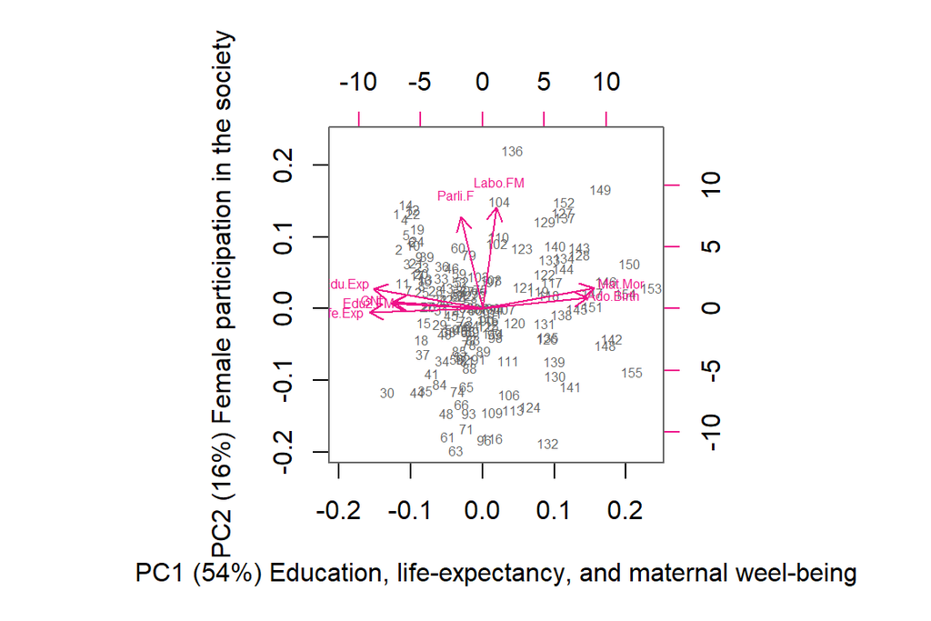

```r
biplot(pca_human2, cex = c(0.5, 0.5), col = c("grey40", "deeppink2"), xlab = "PC1 (54%) Education, life-expectancy, and maternal weel-being", ylab = "PC2 (16%) Female participation in the society")
```

The results of the first PCA based on non-standardized variables differed from those of the second PCA based on standardized variables. In the first, the components represent mainly the variable scales and, consequently, the gross national income per capita (GNI) with much larger values and standard deviation compared to other variables explains, practically, all variation in the data.

**FOURTH, I interpreted the principal components (PC) of the PCA based on the standardized human data.**

The second PC explained 16% of variation in the data. It associated positively with female participation in the society including proportions of females in the labor force and parliament. This PC indicates how well females are able to affect the society via working life and politics.